# Everglades System Conditions Report

Updated: 2026-07-20 09:32:00 EDT

## Purpose

This webpage/report is intended to aggregate information from different agencies (i.e. USACE, SFWMD, FWC, USGS and NOAA) into one spot to help inform local government agencies and stakeholders on conditions within Lake Okeechobee, the Northern Estuaries and the Everglades ecosystem. The data provided here should be considered preliminary and are subject to change.

| Daily discharge volume in Acre-Feet per day for the last 14-days. Data Source: DBHYDRO Date | Daily discharge volume in Acre-Feet per day for the last 14-days. Data Source: DBHYDRO S77 | Daily discharge volume in Acre-Feet per day for the last 14-days. Data Source: DBHYDRO S79 | Daily discharge volume in Acre-Feet per day for the last 14-days. Data Source: DBHYDRO S354 | Daily discharge volume in Acre-Feet per day for the last 14-days. Data Source: DBHYDRO S351 | Daily discharge volume in Acre-Feet per day for the last 14-days. Data Source: DBHYDRO S352 | Daily discharge volume in Acre-Feet per day for the last 14-days. Data Source: DBHYDRO S271 | Daily discharge volume in Acre-Feet per day for the last 14-days. Data Source: DBHYDRO S308 | Daily discharge volume in Acre-Feet per day for the last 14-days. Data Source: DBHYDRO S80 | Daily discharge volume in Acre-Feet per day for the last 14-days. Data Source: DBHYDRO NthLake 1 | Daily discharge volume in Acre-Feet per day for the last 14-days. Data Source: DBHYDRO WCA1 2 | Daily discharge volume in Acre-Feet per day for the last 14-days. Data Source: DBHYDRO WCA2 2 | Daily discharge volume in Acre-Feet per day for the last 14-days. Data Source: DBHYDRO WCA3 2 | Daily discharge volume in Acre-Feet per day for the last 14-days. Data Source: DBHYDRO ENP (SRS) 3 | Daily discharge volume in Acre-Feet per day for the last 14-days. Data Source: DBHYDRO ENP (TSCB) 4 |
| --- | --- | --- | --- | --- | --- | --- | --- | --- | --- | --- | --- | --- | --- | --- |
| 07-19 | 87 | 0 | 0 | 0 | 0 | -42 | 0 | 0 | 543 | 124 | 1500 | 353 | 621 | 0 |
| 07-18 | 216 | 0 | 0 | 0 | 0 | -40 | 0 | 0 | 116 | 321 | 826 | 332 | 640 | 0 |
| 07-17 | 16 | 0 | 0 | 0 | 27 | 6 | 0 | 0 | 256 | 544 | 827 | 437 | 615 | 0 |
| 07-16 | -38 | 680 | 0 | 0 | 26 | 23 | 0 | 0 | 384 | 617 | 324 | 421 | 689 | 0 |
| 07-15 | -125 | 897 | 0 | 0 | 0 | 37 | 0 | 0 | 338 | 72 | 395 | 451 | 680 | 198 |
| 07-14 | -399 | 1188 | 0 | 0 | 0 | 35 | 0 | 0 | 877 | 226 | 348 | 664 | 761 | 458 |
| 07-13 | -347 | 1365 | 0 | 0 | 0 | 37 | 0 | 0 | 587 | 117 | 392 | 407 | 783 | 571 |
| 07-12 | 32 | 908 | 0 | 0 | 0 | 23 | 0 | 0 | 343 | 109 | 501 | 326 | 797 | 897 |
| 07-11 | -180 | 1035 | 0 | 0 | 0 | -10 | 0 | 0 | 478 | 82 | 796 | 378 | 801 | 1126 |
| 07-10 | -165 | 1745 | 0 | 0 | 0 | 19 | 0 | 0 | 590 | 105 | 856 | 217 | 753 | 139 |
| 07-09 | -371 | 1321 | 0 | 0 | 0 | 15 | 0 | 0 | 736 | 220 | 1133 | 246 | 760 | 120 |
| 07-08 | -135 | 1305 | 0 | 0 | 0 | -131 | -1329 | 0 | 953 | 15 | 896 | 263 | 757 | 417 |
| 07-07 | 0 | 2698 | 0 | 0 | 0 | -371 | -3221 | 0 | 983 | 80 | 709 | 418 | 724 | 616 |
| 07-06 | 0 | 1309 | 0 | 0 | 0 | -124 | -738 | 0 | 1482 | 0 | 192 | 385 | 620 | 585 |

1 Includes discharges from Fisheating Creek, S71, S72, S84, S84X, S65E, and S65EX1  
2 Inflow from the EAA.  
3 Estimated as S12s+(S333+S333N)-S356. If no data is present (i.e. -NR-) either S12s, S333s or S356 data is not available.  
4 Estimated as [(S332D-S332DX1-S328)+S328+G737]+S18C.

## Lake Okeechobee

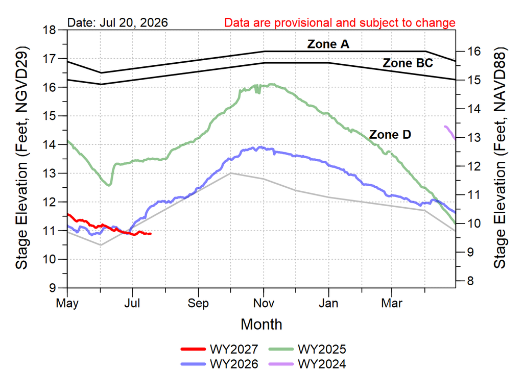

Lake Okeechobee daily average stage elevation for water year 2027 (WY2027) relative to the last three water years relative to the Lake Okeechobee Regulation Schedule (LORS).

Data are provisional and subject to change.

| Stage and recession rates this day for the current and last three water years Date (Month-Day) | Stage and recession rates this day for the current and last three water years Water Year | Stage and recession rates this day for the current and last three water years Stage (ft, NGVD29) | Stage and recession rates this day for the current and last three water years 7-Day Recession Rate (ft 7-d⁻¹) | Stage and recession rates this day for the current and last three water years 30-Day Recession Rate (ft 30-d⁻¹) |
| --- | --- | --- | --- | --- |
| 07-19 | 2024 | - NR - | - NR - | - NR - |
| 07-19 | 2025 | 13.50 | 0.04 | 0.19 |
| 07-19 | 2026 | 11.85 | 0.38 | 0.82 |
| 07-19 | 2027 | - NR - | - NR - | - NR - |

Lake Okeechobee Stage is Ft NGVD29

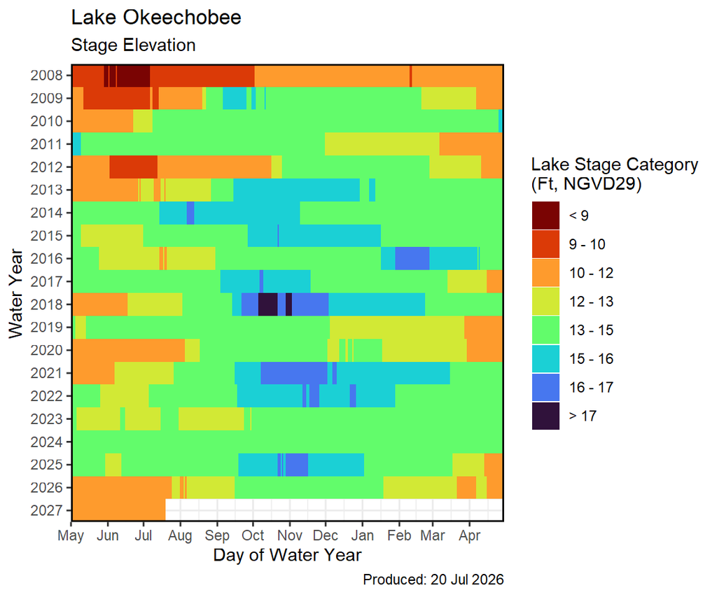

Lake Okeechobee stage calendar plot from 2008 to current.

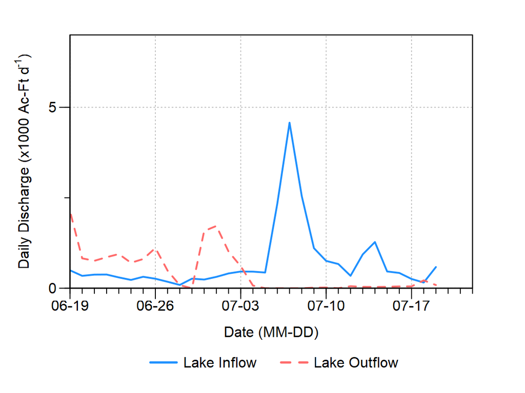

Lake Okeechobee inflow and outflow volume from USACE.

**Lake Flows:** In the past 7 days the total outflow from Lake Okeechobee was **511 AF** with **320 AF** to the Caloosahatchee through **S-77**, 0 AF** through **S-308** in Port Mayaca and **192 AF** to the EAA through **S-351**, **S-352**, and **S-354**. The total net inflow to the Lake was **4,091 AF** (3,100 AF from Fisheating Creek, S-71, S-72, S-84s, S-65EX, and S-65EX1)

### Lake Okeechobee Cyano HAB

Data from NOAA NCCOS, HAB Monitoring Products ([link](https://coastalscience.noaa.gov/science-areas/habs/hab-monitoring-system/))

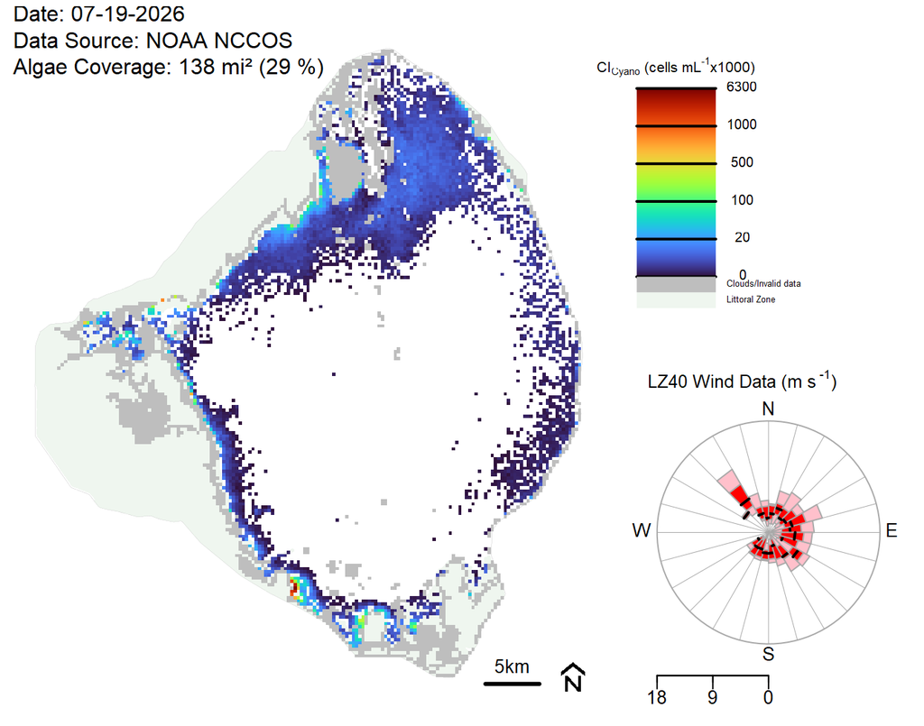

Cyanobacteria Algal Index across Lake Okeechobee. Percent area based on open water coverage (Lake Area minus Littoral Zone). Windrose plot (bottom right) summarizing breakpoint wind data for the last 3 days using Tukey five-number summarise (i.e. boxplot). HAB Data from NOAA NCCOS HAB data explorer. Wind Data from SFWMD site LZ40.Data are provisional and subject to change.

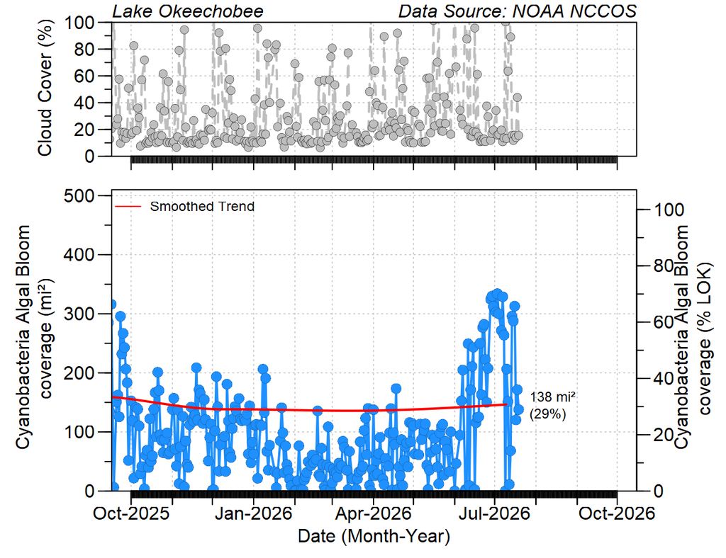

Daily cloud cover and cyanobacteria algal bloom coverage of Lake Okeechobee. Percent area based on open water coverage (Lake Area minus Littoral Zone). Data from NOAA NCCOS HAB data explorer.Data are provisional and subject to change.

## Everglades Agricultural Area

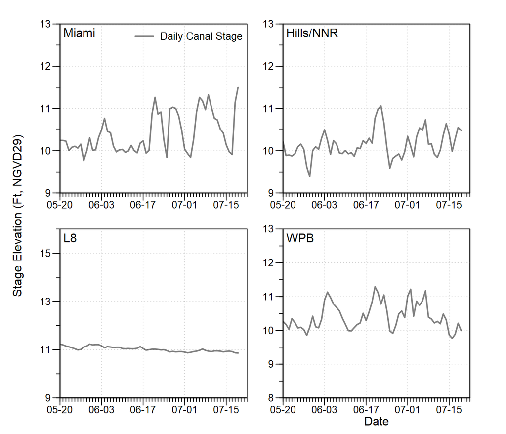

EAA canal stage.

## Water Conservation Area 1

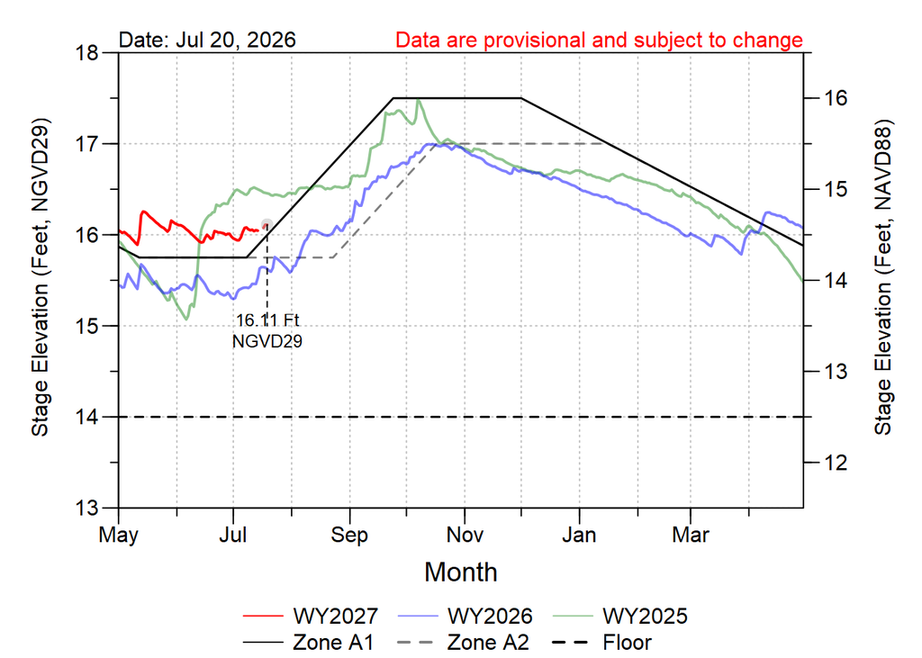

Water Conservation Area 1 (WCA1/LNWR) daily average stage elevation for water year 2027 (WY2027) relative to the last two water years relative to the WCA1 Regulation Schedule.

Data are provisional and subject to change.

| Stage and recession rates this time for the current and last three water years Date (Month-Day) | Stage and recession rates this time for the current and last three water years Water Year | Stage and recession rates this time for the current and last three water years Stage (ft, NGVD29) | Stage and recession rates this time for the current and last three water years 7-Day Recession Rate (ft 7-d⁻¹) | Stage and recession rates this time for the current and last three water years 30-Day Recession Rate (ft 30-d⁻¹) |
| --- | --- | --- | --- | --- |
| 07-19 | 2024 | 16.46 | 0.04 | 0.19 |
| 07-19 | 2025 | 16.45 | -0.07 | 0.23 |
| 07-19 | 2026 | 15.62 | 0.16 | 0.26 |
| 07-19 | 2027 | 16.11 | 0.07 | 0.15 |

WCA1 Stage is 0.11 Ft NGVD29 above A1 line

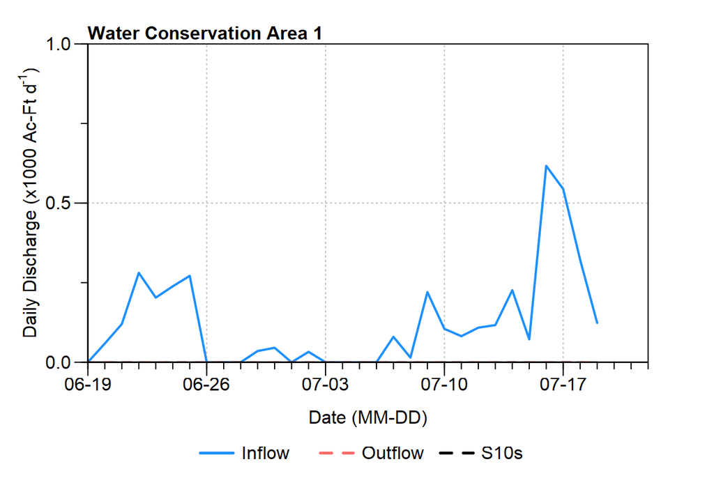

WCA1 inflow and outflow volume from DBHYDRO

## Water Conservation Area 2

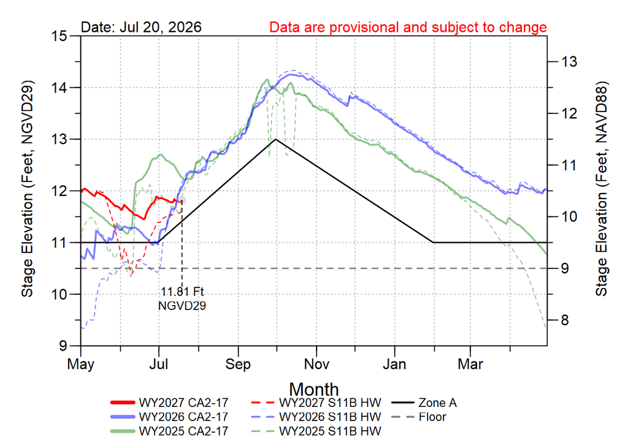

Water Conservation Area 2A (WCA2A) daily average stage elevation for water year 2027 (WY2027) relative to the last two water years relative to the WCA2A Regulation Schedule.

Data are provisional and subject to change.

| Stage and recession rates this time for the current and last three water years Date (Month-Day) | Stage and recession rates this time for the current and last three water years Water Year | Stage and recession rates this time for the current and last three water years Stage (ft, NGVD29) A | Stage and recession rates this time for the current and last three water years 7-Day Recession Rate (ft 7-d⁻¹) A | Stage and recession rates this time for the current and last three water years 30-Day Recession Rate (ft 30-d⁻¹) A |
| --- | --- | --- | --- | --- |
| 07-19 | 2024 | 12.92 | -0.08 | 0.05 |
| 07-19 | 2025 | 12.26 | -0.26 | -0.01 |
| 07-19 | 2026 | 12.07 | 0.42 | 0.93 |
| 07-19 | 2027 | 11.81 | 0.03 | 0.36 |

A Value represented by CA2-17

WCA-2 Stage is 0.4 Ft NGVD29 above Zone A

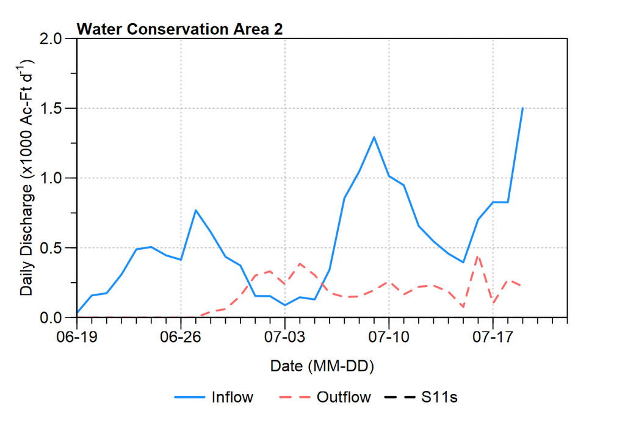

WCA2 inflow and outflow volume from DBHYDRO

## Water Conservation Area 3

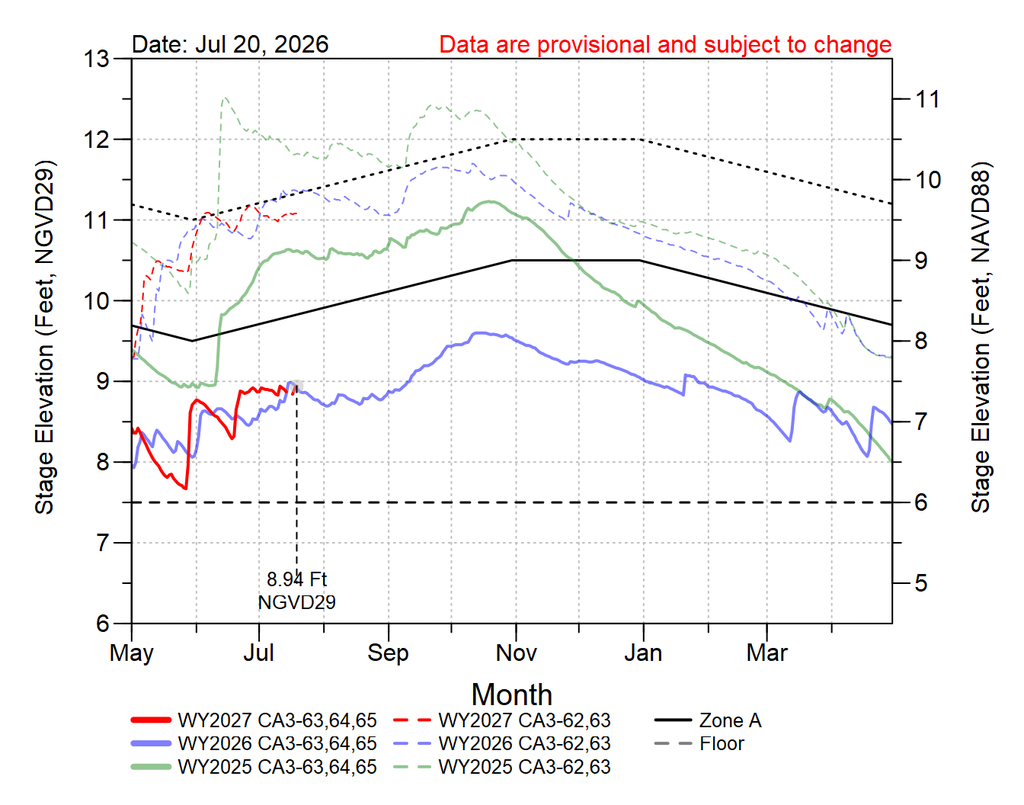

Water Conservation Area 3A (WCA3A) daily average stage elevation for water year 2027 (WY2027) relative to the last two water years relative to the WCA3A Regulation Schedule. Average stage values represented by the 3-gauge average (3-63,3-64,3-65) and 2-gauge average (3-62 and 3-63).

Data are provisional and subject to change.

| Stage and recession rates this time for the current and last three water years Date (Month-Day) | Stage and recession rates this time for the current and last three water years Water Year | Stage and recession rates this time for the current and last three water years Stage (ft, NGVD29) A | Stage and recession rates this time for the current and last three water years 7-Day Recession Rate (ft 7-d⁻¹) A | Stage and recession rates this time for the current and last three water years 30-Day Recession Rate (ft 30-d⁻¹) A |
| --- | --- | --- | --- | --- |
| 07-19 | 2024 | 10.14 | 0.04 | 1.11 |
| 07-19 | 2025 | 10.62 | 0.02 | 0.69 |
| 07-19 | 2026 | 8.91 | 0.17 | 0.38 |
| 07-19 | 2027 | 8.94 | 0.02 | 0.62 |

A Value represented by 3-gauge average (3-63, 3-64 and 3-65)

WCA-3 Stage is 0.89 Ft NGVD29 below Zone A

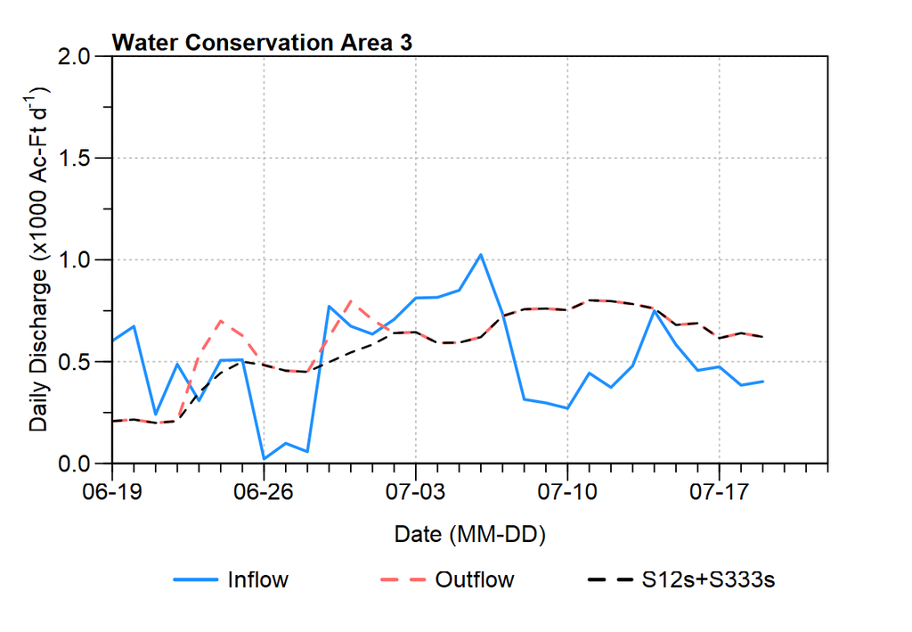

WCA3A inflow and outflow volume from DBHYDRO.

## Redline (WCAs) Inflows

| Red line (i.e. inflows to WCAs) discharges (x1000 Ac-Ft) Year | Red line (i.e. inflows to WCAs) discharges (x1000 Ac-Ft) Jan | Red line (i.e. inflows to WCAs) discharges (x1000 Ac-Ft) Feb | Red line (i.e. inflows to WCAs) discharges (x1000 Ac-Ft) Mar | Red line (i.e. inflows to WCAs) discharges (x1000 Ac-Ft) Apr | Red line (i.e. inflows to WCAs) discharges (x1000 Ac-Ft) May | Red line (i.e. inflows to WCAs) discharges (x1000 Ac-Ft) Jun | Red line (i.e. inflows to WCAs) discharges (x1000 Ac-Ft) Jul * | Red line (i.e. inflows to WCAs) discharges (x1000 Ac-Ft) Aug | Red line (i.e. inflows to WCAs) discharges (x1000 Ac-Ft) Sep | Red line (i.e. inflows to WCAs) discharges (x1000 Ac-Ft) Oct | Red line (i.e. inflows to WCAs) discharges (x1000 Ac-Ft) Nov | Red line (i.e. inflows to WCAs) discharges (x1000 Ac-Ft) Dec | Red line (i.e. inflows to WCAs) discharges (x1000 Ac-Ft) Total |
| --- | --- | --- | --- | --- | --- | --- | --- | --- | --- | --- | --- | --- | --- |
| 2012 | 0.0 | 0.0 | 0.0 | 0.0 | 63.6 | 54.2 | 46.5 | 153.1 | 233.9 | 81.1 | 7.9 | 28.3 | 668.5 |
| 2013 | 3.0 | 40.1 | 17.8 | 43.0 | 47.0 | 192.8 | 230.2 | 72.0 | 148.3 | 71.4 | 8.9 | 17.3 | 888.7 |
| 2014 | 30.7 | 87.5 | 11.4 | 8.2 | 14.2 | 79.4 | 97.4 | 169.4 | 169.9 | 85.9 | 22.6 | 66.1 | 812.1 |
| 2015 | 61.1 | 58.9 | 44.4 | 12.8 | 9.3 | 26.0 | 39.1 | 113.4 | 208.2 | 103.4 | 49.5 | 71.1 | 736.2 |
| 2016 | 161.8 | 173.9 | 25.8 | 35.9 | 79.0 | 89.0 | 62.6 | 141.6 | 141.9 | 119.9 | 21.2 | 38.0 | 928.9 |
| 2017 | 28.3 | 23.4 | 21.8 | 17.1 | 66.1 | 277.7 | 78.5 | 108.1 | 264.7 | 237.9 | 87.0 | 19.1 | 1201.5 |
| 2018 | 19.6 | 41.7 | 31.5 | 51.8 | 180.5 | 84.9 | 126.1 | 86.6 | 90.3 | 56.7 | 39.4 | 35.1 | 824.5 |
| 2019 | 70.9 | 76.4 | 21.9 | 3.4 | 59.4 | 89.1 | 119.9 | 210.6 | 64.5 | 45.8 | 25.9 | 35.9 | 752.7 |
| 2020 | 28.6 | 26.0 | 13.1 | 6.5 | 69.3 | 158.3 | 105.5 | 127.2 | 157.0 | 198.3 | 208.7 | 56.5 | 1126.2 |
| 2021 | 6.9 | 4.2 | 25.5 | 35.1 | 14.3 | 49.5 | 99.4 | 146.6 | 163.9 | 100.4 | 56.9 | 13.7 | 709.5 |
| 2022 | 8.7 | 9.5 | 13.5 | 5.7 | 30.5 | 190.6 | 47.4 | 15.0 | 173.0 | 165.4 | 63.2 | 32.4 | 746.0 |
| 2023 | 15.3 | 15.2 | 15.3 | 34.3 | 35.9 | 151.7 | 112.9 | 128.4 | 134.6 | 122.7 | 61.7 | 71.9 | 884.5 |
| 2024 | 85.9 | 50.1 | 57.4 | 13.1 | 3.6 | 153.5 | 88.4 | 78.5 | 185.4 | 91.2 | 12.5 | 26.3 | 759.8 |
| 2025 | 39.4 | 32.1 | 9.7 | 12.2 | 19.7 | 23.5 | 67.4 | 23.4 | 84.4 | 72.4 | 4.5 | 2.8 | 351.9 |
| 2026 | 1.2 | 0.9 | 19.2 | 51.2 | 9.2 | 8.4 | 17.1 | 0.0 | 0.0 | 0.0 | 0.0 | 0.0 | 106.1 |

Note: All data is from DBHYDRO and provisional.  
* The latest month value may include an incomplete monthly period of record.

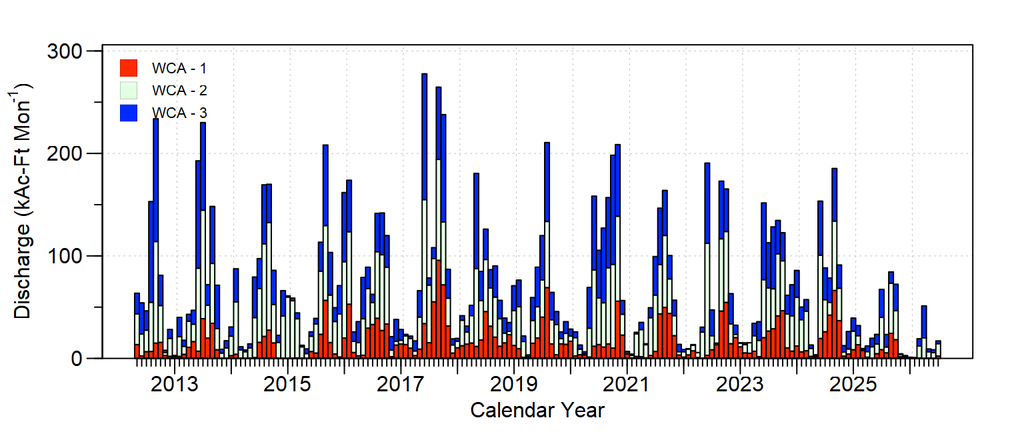

Discharges across the Red line (northern inflows to WCAs) from January 2012 to current.

## Everglades National Park

### Stages

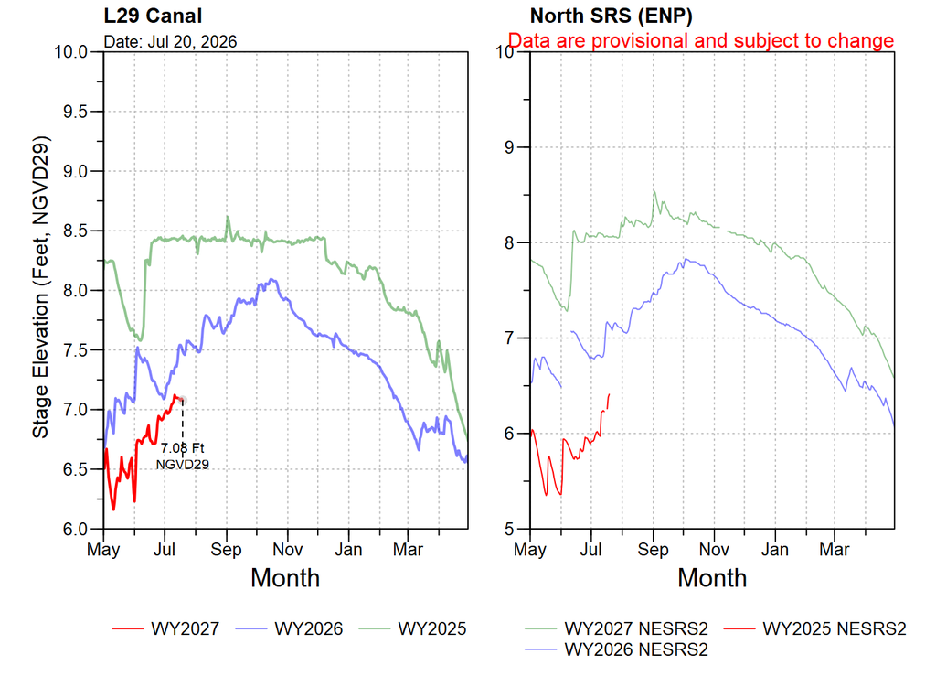

Daily average stage elevation for water year 2027 (WY2027) relative to the last two water years in Everglades National Park.

Data are provisional and subject to change.

| Stage (Ft, NGVD29) this time for the current and last three water years Date (Month-Day) | Stage (Ft, NGVD29) this time for the current and last three water years Water Year | Stage (Ft, NGVD29) this time for the current and last three water years L29 | Stage (Ft, NGVD29) this time for the current and last three water years NESRS2 | Stage (Ft, NGVD29) this time for the current and last three water years NP201 |
| --- | --- | --- | --- | --- |
| 07-19 | 2024 | 8.47 | 8.19 |  |
| 07-19 | 2025 | 8.46 | 8.06 |  |
| 07-19 | 2026 | 7.49 | 7.14 |  |
| 07-19 | 2027 | 7.08 | 6.41 |  |

### Discharge

| Daily discharge volume in acre-feet per day for the last 14-days. Data Source: SFWMD DBHYDRO Date | Daily discharge volume in acre-feet per day for the last 14-days. Data Source: SFWMD DBHYDRO S12A | Daily discharge volume in acre-feet per day for the last 14-days. Data Source: SFWMD DBHYDRO S12B | Daily discharge volume in acre-feet per day for the last 14-days. Data Source: SFWMD DBHYDRO S12C | Daily discharge volume in acre-feet per day for the last 14-days. Data Source: SFWMD DBHYDRO S12D | Daily discharge volume in acre-feet per day for the last 14-days. Data Source: SFWMD DBHYDRO S333N | Daily discharge volume in acre-feet per day for the last 14-days. Data Source: SFWMD DBHYDRO S333 | Daily discharge volume in acre-feet per day for the last 14-days. Data Source: SFWMD DBHYDRO S334 | Daily discharge volume in acre-feet per day for the last 14-days. Data Source: SFWMD DBHYDRO S335 | Daily discharge volume in acre-feet per day for the last 14-days. Data Source: SFWMD DBHYDRO S355A | Daily discharge volume in acre-feet per day for the last 14-days. Data Source: SFWMD DBHYDRO S355B | Daily discharge volume in acre-feet per day for the last 14-days. Data Source: SFWMD DBHYDRO S356 | Daily discharge volume in acre-feet per day for the last 14-days. Data Source: SFWMD DBHYDRO Total Inflow 1 |
| --- | --- | --- | --- | --- | --- | --- | --- | --- | --- | --- | --- | --- |
| 07-19 | 0 | 0 | 0 | 31 | 591 | 0 | 0 | 0 | 0 | 0 | 0 | 621 |
| 07-18 | 0 | 0 | 0 | 34 | 606 | 0 | 0 | 0 | 0 | 0 | 0 | 640 |
| 07-17 | 0 | 0 | 0 | 32 | 584 | 0 | 0 | 0 | 0 | 0 | 0 | 615 |
| 07-16 | 0 | 0 | 0 | 0 | 689 | 0 | 0 | 0 | 0 | 0 | 0 | 689 |
| 07-15 | 0 | 0 | 0 | 0 | 680 | 0 | 0 | 0 | 0 | 0 | 0 | 680 |
| 07-14 | 0 | 0 | 0 | 42 | 719 | 0 | 0 | 0 | 0 | 0 | 0 | 761 |
| 07-13 | 0 | 0 | 0 | 49 | 734 | 0 | 0 | 0 | 0 | 0 | 0 | 783 |
| 07-12 | 0 | 0 | 0 | 59 | 738 | 0 | 0 | 0 | 0 | 0 | 0 | 797 |
| 07-11 | 0 | 0 | 0 | 59 | 742 | 0 | 0 | 0 | 0 | 0 | 0 | 801 |
| 07-10 | 0 | 0 | 0 | 48 | 705 | 0 | 0 | 0 | 0 | 0 | 0 | 753 |
| 07-09 | 0 | 0 | 0 | 61 | 699 | 0 | 0 | 0 | 0 | 0 | 0 | 760 |
| 07-08 | 0 | 0 | 0 | 79 | 678 | 0 | 0 | 0 | 0 | 0 | 0 | 757 |
| 07-07 | 0 | 0 | 0 | 98 | 626 | 0 | 0 | 0 | 0 | 0 | 0 | 724 |
| 07-06 | 0 | 0 | 0 | 86 | 534 | 0 | 0 | 0 | 0 | 0 | 0 | 620 |

1 Estimated as S12s+(S333+S333N+S355s+min(S356,S335)-S334).

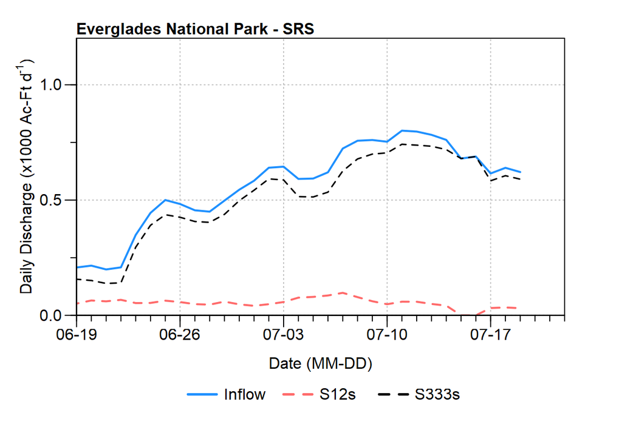

Shark River Slough calculated net inflow.

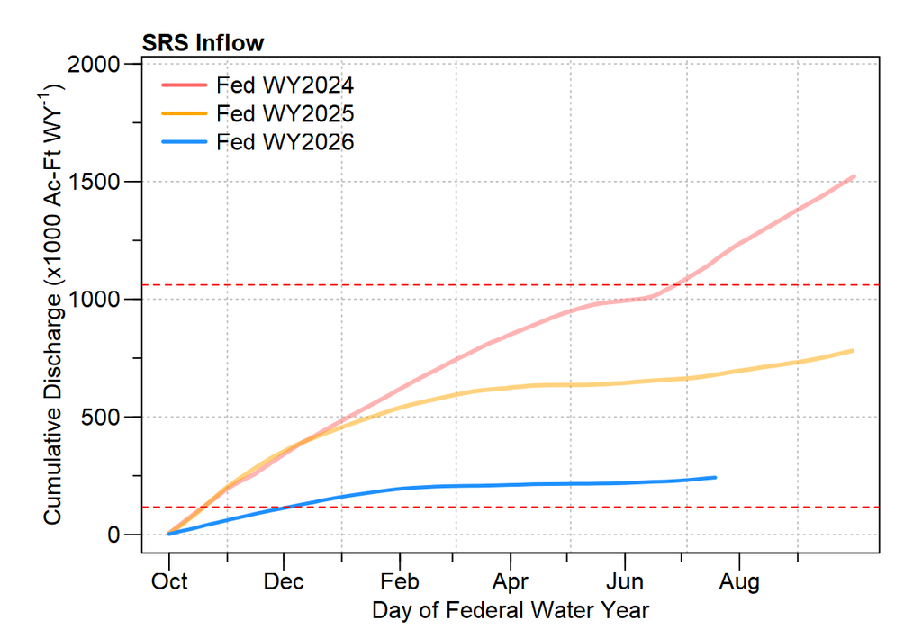

Cumulative discharge for Shark River Slough for the last three Federal Water Years (Oct - Sept). Day of water year is analogous to day of year with Day 1 = October 1.

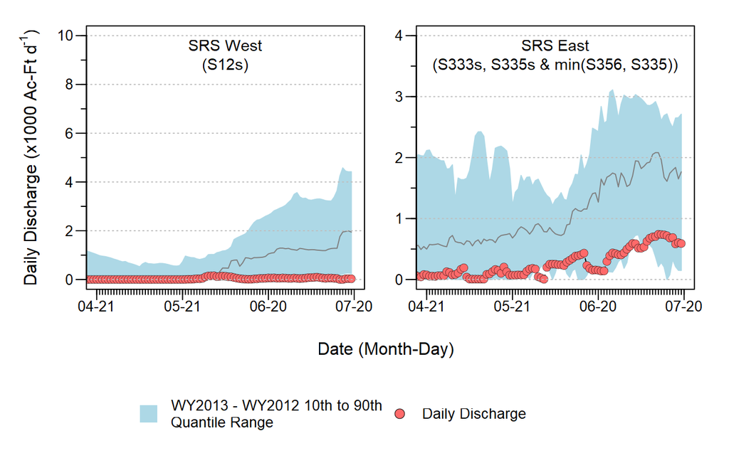

Shark River Slough daily discharge relative to historic peroid of record summary statistics.

### Water Deliveries across Tamiami Trail

| Water Deliveries (Ac-Ft) to L-29 Canal (S12s + S333 + S333N + S356 - S334) Year | Water Deliveries (Ac-Ft) to L-29 Canal (S12s + S333 + S333N + S356 - S334) Jan | Water Deliveries (Ac-Ft) to L-29 Canal (S12s + S333 + S333N + S356 - S334) Feb | Water Deliveries (Ac-Ft) to L-29 Canal (S12s + S333 + S333N + S356 - S334) Mar | Water Deliveries (Ac-Ft) to L-29 Canal (S12s + S333 + S333N + S356 - S334) Apr | Water Deliveries (Ac-Ft) to L-29 Canal (S12s + S333 + S333N + S356 - S334) May | Water Deliveries (Ac-Ft) to L-29 Canal (S12s + S333 + S333N + S356 - S334) Jun | Water Deliveries (Ac-Ft) to L-29 Canal (S12s + S333 + S333N + S356 - S334) Jul * | Water Deliveries (Ac-Ft) to L-29 Canal (S12s + S333 + S333N + S356 - S334) Aug | Water Deliveries (Ac-Ft) to L-29 Canal (S12s + S333 + S333N + S356 - S334) Sep | Water Deliveries (Ac-Ft) to L-29 Canal (S12s + S333 + S333N + S356 - S334) Oct | Water Deliveries (Ac-Ft) to L-29 Canal (S12s + S333 + S333N + S356 - S334) Nov | Water Deliveries (Ac-Ft) to L-29 Canal (S12s + S333 + S333N + S356 - S334) Dec | Water Deliveries (Ac-Ft) to L-29 Canal (S12s + S333 + S333N + S356 - S334) Total |
| --- | --- | --- | --- | --- | --- | --- | --- | --- | --- | --- | --- | --- | --- |
| 2012 | 0 | 0 | 0 | 0 | 26,034 | 45,491 | 71,109 | 87,417 | 114,808 | 177,789 | 123,074 | 105,343 | 751,065 |
| 2013 | 39,519 | 14,062 | 3,235 | 186 | 52,113 | 66,042 | 112,300 | 149,898 | 133,138 | 122,563 | 87,956 | 40,798 | 821,810 |
| 2014 | 6,304 | 44,023 | 56,087 | 380 | -47 | 12,961 | 65,662 | 76,190 | 102,184 | 100,487 | 91,506 | 23,244 | 578,981 |
| 2015 | 12,985 | 15,096 | 8,475 | -1 | 28 | 0 | 9 | 1 | 19,245 | 133,198 | 72,730 | 136,308 | 398,074 |
| 2016 | 125,772 | 181,001 | 216,772 | 145,309 | 62,775 | 37,361 | 53,291 | 76,905 | 107,954 | 119,027 | 77,561 | 7,439 | 1,211,167 |
| 2017 | 2,472 | 4,724 | 1,218 | 35 | -12 | 101,145 | 188,662 | 167,042 | 243,323 | 381,186 | 283,003 | 185,557 | 1,558,355 |
| 2018 | 85,122 | 37,620 | 2,482 | 515 | 34,525 | 119,446 | 162,335 | 164,173 | 164,499 | 131,953 | 1,088 | 106 | 903,864 |
| 2019 | 394 | 22,345 | 30,482 | 16,982 | 27,842 | 63,731 | 120,588 | 139,501 | 163,231 | 116,651 | 26,951 | -210 | 728,488 |
| 2020 | -316 | -217 | 451 | 1,092 | 10,351 | 102,960 | 161,688 | 177,729 | 160,090 | 203,345 | 378,783 | 354,238 | 1,550,194 |
| 2021 | 198,340 | 140,249 | 123,687 | 75,383 | 28,031 | 32,653 | 72,835 | 102,451 | 119,829 | 185,721 | 159,423 | 148,747 | 1,387,349 |
| 2022 | 122,871 | 87,238 | 70,179 | 32,754 | 9,205 | 101,347 | 167,199 | 140,226 | 111,241 | 216,253 | 173,153 | 147,213 | 1,378,879 |
| 2023 | 117,088 | 80,975 | 59,073 | 56,677 | 65,966 | 101,965 | 155,718 | 162,134 | 170,238 | 193,532 | 149,735 | 154,908 | 1,468,009 |
| 2024 | 146,983 | 133,678 | 126,639 | 104,880 | 55,919 | 96,172 | 180,733 | 162,711 | 154,480 | 209,663 | 171,457 | 116,789 | 1,660,104 |
| 2025 | 95,449 | 53,942 | 34,093 | 11,999 | 8,337 | 21,078 | 34,365 | 44,049 | 70,119 | 77,550 | 52,290 | 48,082 | 551,353 |
| 2026 | 34,676 | 12,226 | 5,022 | 4,318 | 3,419 | 10,635 | 13,056 | 0 | 0 | 0 | 0 | 0 | 83,352 |

Note: All data is from DBHYDRO and provisional.  
Structure (DBKEY): S12A (01313); S12B (00610); S12C (00621); S12D (01310); S333N (40371); S333 (91487); S334 (91488); S355A (MQ895); S355B (AM173); S355B (MQ896); S356 (64136)  
* The latest month value may include an incomplete monthly period of record.

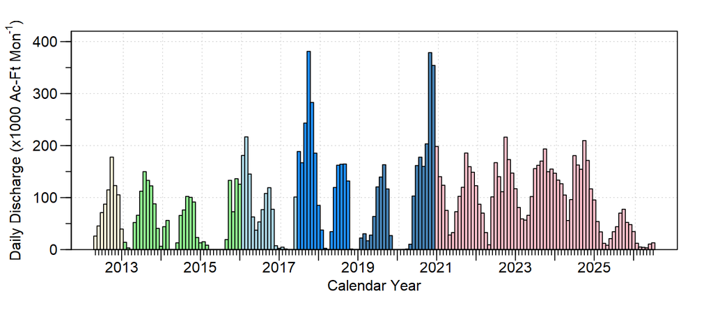

Water Deliveries into Shark River Slough (S12s + S333 + S333N + S356 - S334) from January 2012 to current. Color correspond to operational changes reflected in the table above.

| Water Deliveries (Ac-Ft) to L-29 Canal (S333 + S333N + S356 - S334) Year | Water Deliveries (Ac-Ft) to L-29 Canal (S333 + S333N + S356 - S334) Jan | Water Deliveries (Ac-Ft) to L-29 Canal (S333 + S333N + S356 - S334) Feb | Water Deliveries (Ac-Ft) to L-29 Canal (S333 + S333N + S356 - S334) Mar | Water Deliveries (Ac-Ft) to L-29 Canal (S333 + S333N + S356 - S334) Apr | Water Deliveries (Ac-Ft) to L-29 Canal (S333 + S333N + S356 - S334) May | Water Deliveries (Ac-Ft) to L-29 Canal (S333 + S333N + S356 - S334) Jun | Water Deliveries (Ac-Ft) to L-29 Canal (S333 + S333N + S356 - S334) Jul * | Water Deliveries (Ac-Ft) to L-29 Canal (S333 + S333N + S356 - S334) Aug | Water Deliveries (Ac-Ft) to L-29 Canal (S333 + S333N + S356 - S334) Sep | Water Deliveries (Ac-Ft) to L-29 Canal (S333 + S333N + S356 - S334) Oct | Water Deliveries (Ac-Ft) to L-29 Canal (S333 + S333N + S356 - S334) Nov | Water Deliveries (Ac-Ft) to L-29 Canal (S333 + S333N + S356 - S334) Dec | Water Deliveries (Ac-Ft) to L-29 Canal (S333 + S333N + S356 - S334) Total |
| --- | --- | --- | --- | --- | --- | --- | --- | --- | --- | --- | --- | --- | --- |
| 2012 | 0 | 0 | 0 | 0 | 15,468 | 14,654 | 382 | 3,436 | -534 | -451 | -441 | 7,889 | 40,403 |
| 2013 | 18,215 | 7,652 | 1,537 | 2 | 30,583 | 20,438 | 3,284 | 1,606 | -2,210 | -803 | -13 | 0 | 80,291 |
| 2014 | 723 | 30,006 | 31,587 | 166 | -47 | 10,522 | 48,685 | 16,637 | 17,087 | 2 | 32,095 | 12,030 | 199,493 |
| 2015 | 1,574 | 0 | 5,298 | -1 | 28 | 0 | 9 | 1 | 11,172 | 47,731 | 42,204 | 18,825 | 126,841 |
| 2016 | 18,617 | 29,882 | 85,883 | 84,540 | 33,870 | 6,643 | 20,772 | 10,176 | -305 | 170 | 67 | 7,124 | 297,439 |
| 2017 | 2,472 | 4,724 | 1,218 | 35 | -12 | 35,974 | 11,692 | -138 | 24,492 | -178 | 4,708 | 54,827 | 139,814 |
| 2018 | 11,031 | 21,853 | 2,482 | 515 | 15,033 | 32,052 | 64,643 | 77,709 | 55,232 | 80,825 | 1,088 | 106 | 362,569 |
| 2019 | 394 | 22,345 | 24,404 | 16,982 | 27,842 | 60,589 | 99,756 | 80,782 | 94,907 | 75,748 | 26,951 | -210 | 530,490 |
| 2020 | -316 | -217 | 451 | 1,092 | 10,351 | 74,156 | 109,147 | 100,771 | 77,203 | 49,876 | 27,367 | 7,031 | 456,912 |
| 2021 | 46,586 | 83,373 | 98,068 | 65,541 | 26,738 | 31,737 | 59,761 | 71,474 | 81,658 | 86,146 | 69,489 | 106,333 | 826,904 |
| 2022 | 97,842 | 69,264 | 58,222 | 31,256 | 7,856 | 80,756 | 106,731 | 101,241 | 73,959 | 73,078 | 69,398 | 60,599 | 830,202 |
| 2023 | 63,303 | 60,777 | 48,282 | 46,081 | 49,213 | 69,265 | 84,048 | 66,419 | 37,771 | 23,298 | 27,206 | 31,733 | 607,396 |
| 2024 | 39,848 | 43,466 | 39,525 | 61,711 | 48,474 | 50,707 | 65,573 | 42,897 | 22,111 | 31,765 | 50,455 | 46,385 | 542,917 |
| 2025 | 49,573 | 33,154 | 29,665 | 10,485 | 7,455 | 19,295 | 31,056 | 39,070 | 40,066 | 54,782 | 36,208 | 33,836 | 384,645 |
| 2026 | 29,741 | 11,921 | 4,486 | 4,262 | 2,859 | 8,679 | 12,074 | 0 | 0 | 0 | 0 | 0 | 74,022 |

Note: All data is from DBHYDRO and provisional.  
Structure (DBKEY): S333N (40371); S333 (91487); S334 (91488); S356 (64136)  
* The latest month value may include an incomplete monthly period of record.

| LEGEND |
| --- |
| IOP |
| ERTP |
| Increment 1 |
| 2016 Emergency Deviation |
| Increment 1.1/1.2 |
| 2017 Temporary Deviation |
| Increment 2 |
| COP |
| 2020 Temporary Deviation |
| 2023 Temporary Deviation |

### Florida Bay

#### Creek Discharge

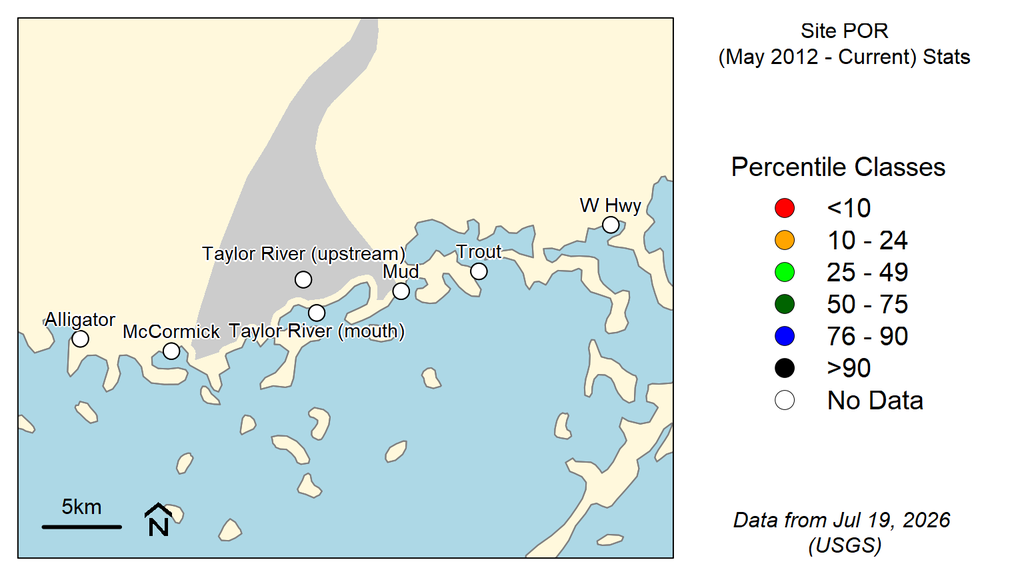

Creek discharge relative to the period of record percentiles.

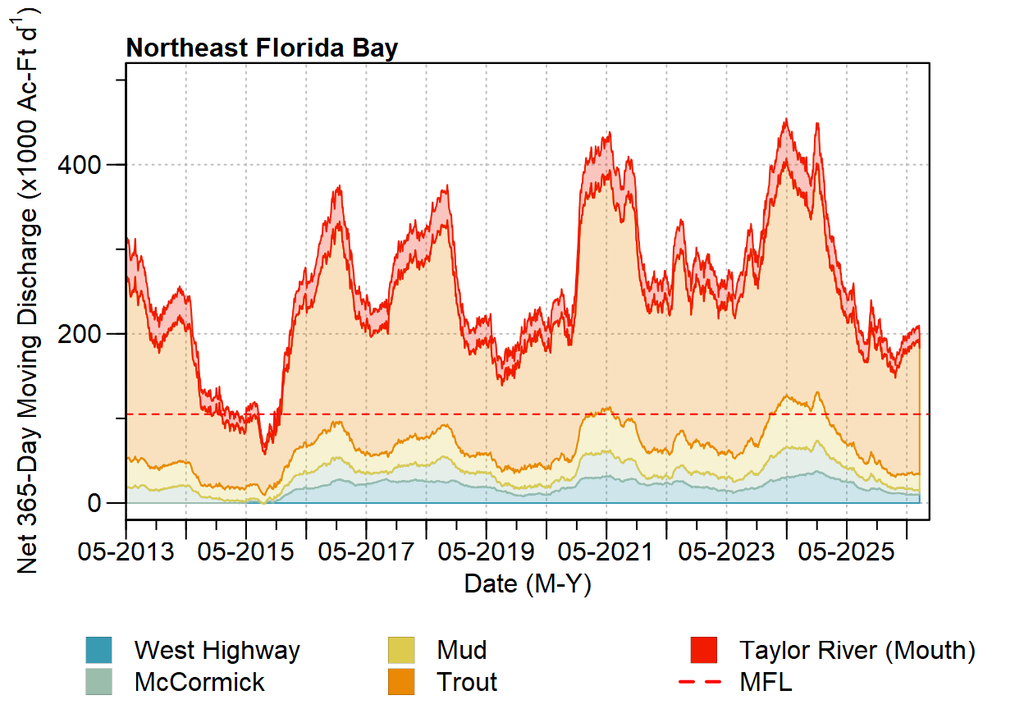

NE Florida Bay net discharge volumes.

#### Salinity

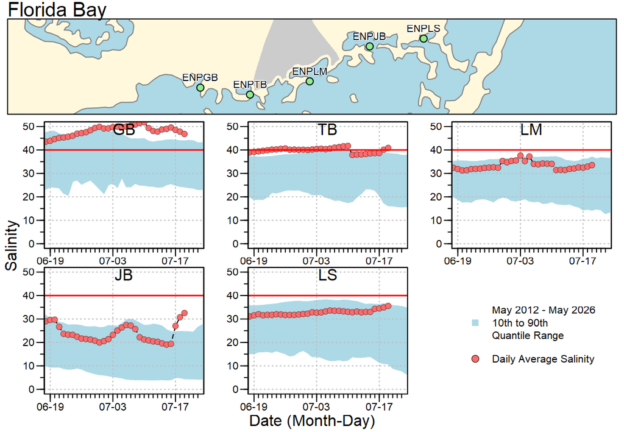

Daily salinity values for select Florida Bay salinity mointoring locations relative to site specific daily historic statistics.

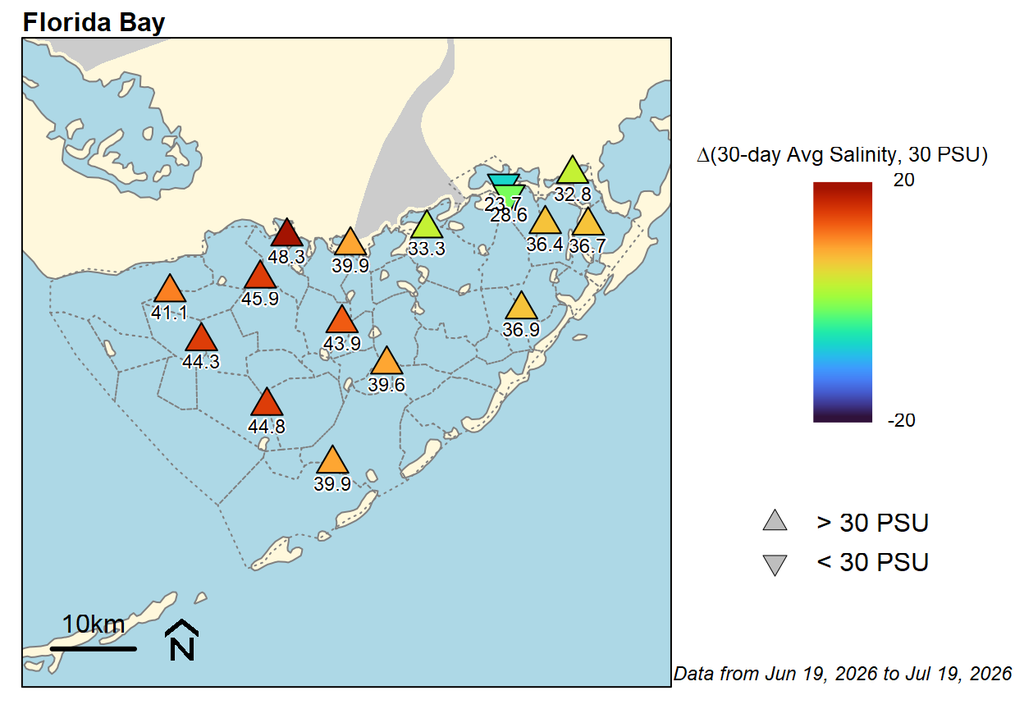

30-day average salinity relative to 30 psu for sites across Florida Bay.

### West Coast

#### Creek Discharge

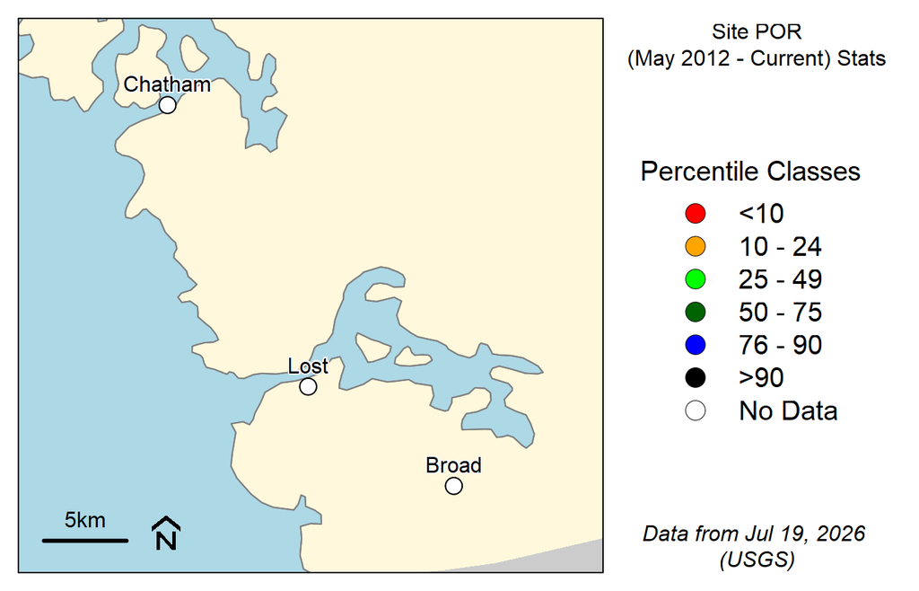

Creek discharge relative to the period of record percentiles.

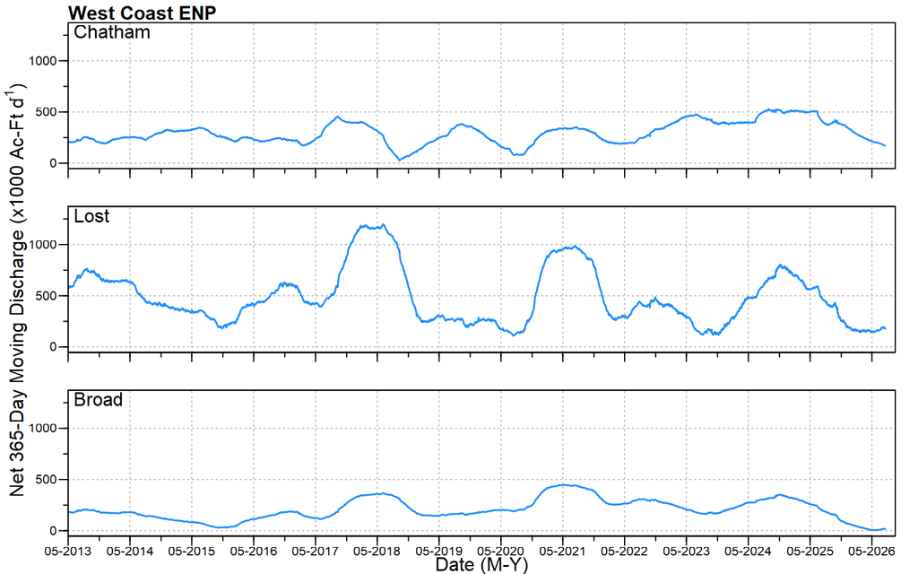

Net 365-day moving sum creek flows for select locations along the west coast of ENP.

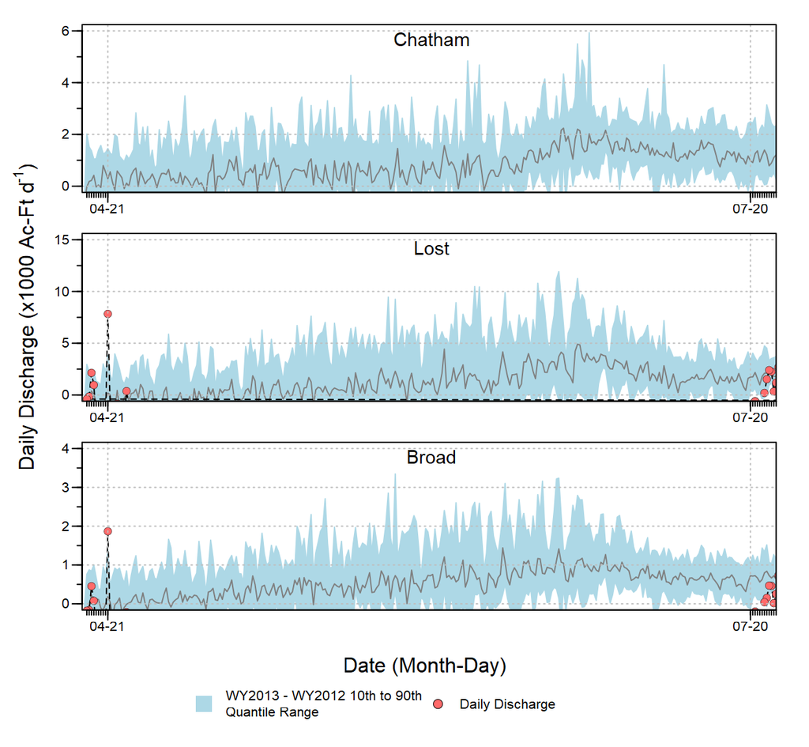

West Coast creeks daily discharge relative to historic peroid of record summary statistics.

#### Salinity

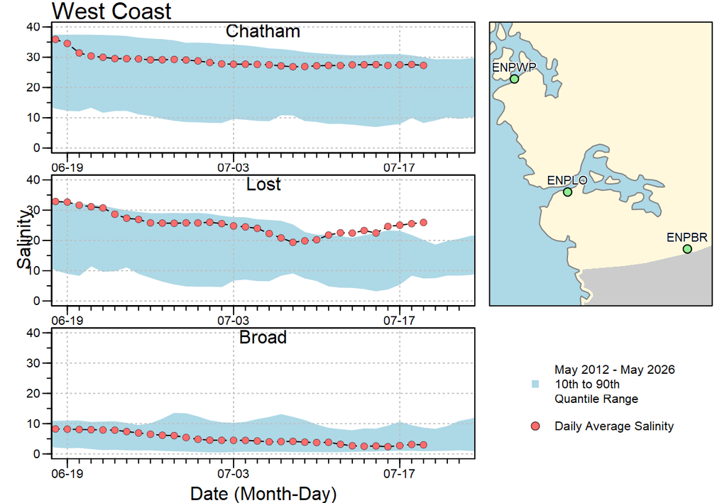

Daily salinity values for select West Coast creek salinity mointoring locations relative to site specific daily historic statistics.

# Northern Estuaries

## Caloosahatchee River Estuary

### Discharge Conditions

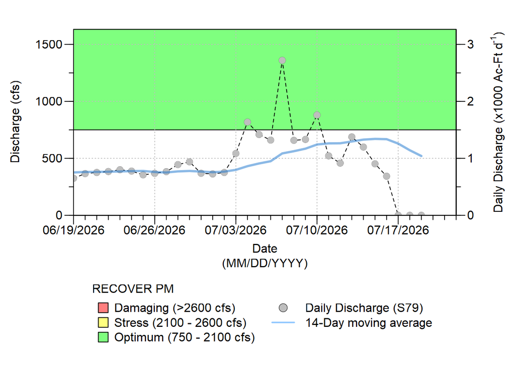

Daily and 14-day moving average discharge for S-79 relative to the Northern Estuaries RECOVER performance measure for the recent 30-day period.

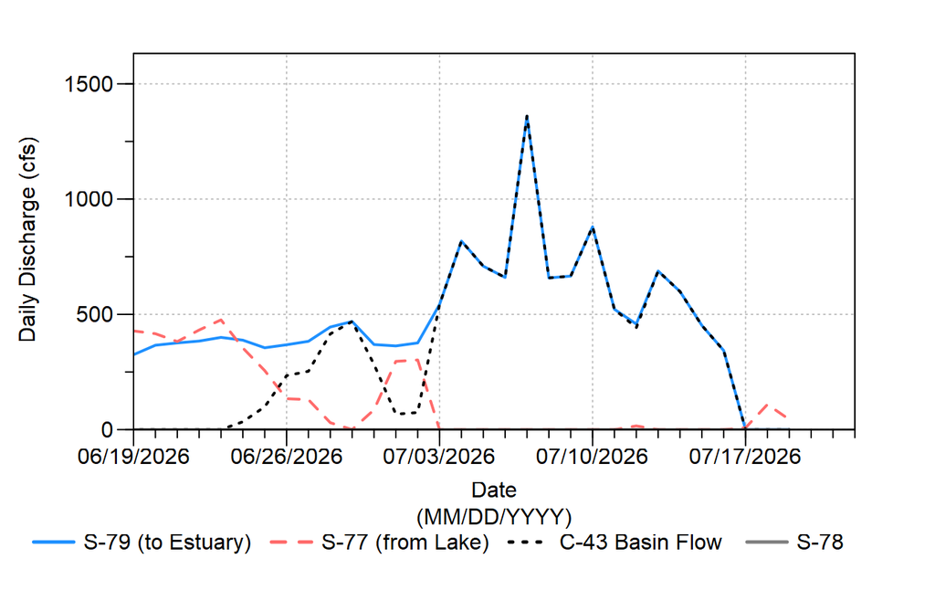

S-77 (from Lake Okeechobee) and S-79 (to Tidal Basin) flow data along the C-43 and Caloosahatchee River. C-43 Basin Flow was calculated as the difference from S-77 and S-79.

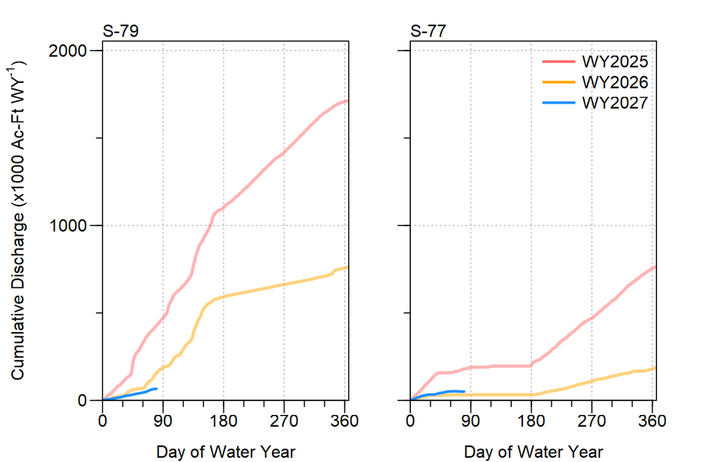

Cumulative discharge for S-79 (to Tidal Basin) and S-77 (from Lake Okeechobee) for the last three Florida Water Years (May - April). Day of water year is analogous to day of year with Day 1 = May 1.

### Salinity

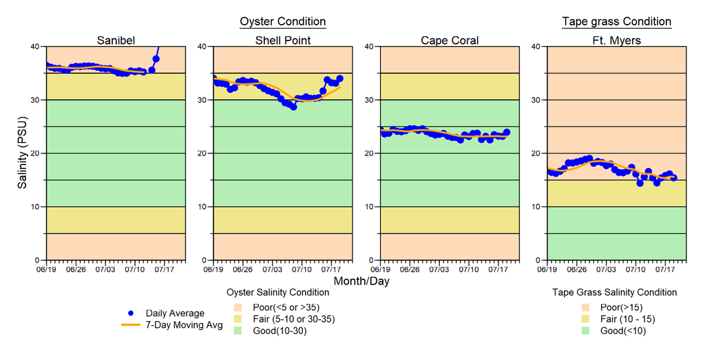

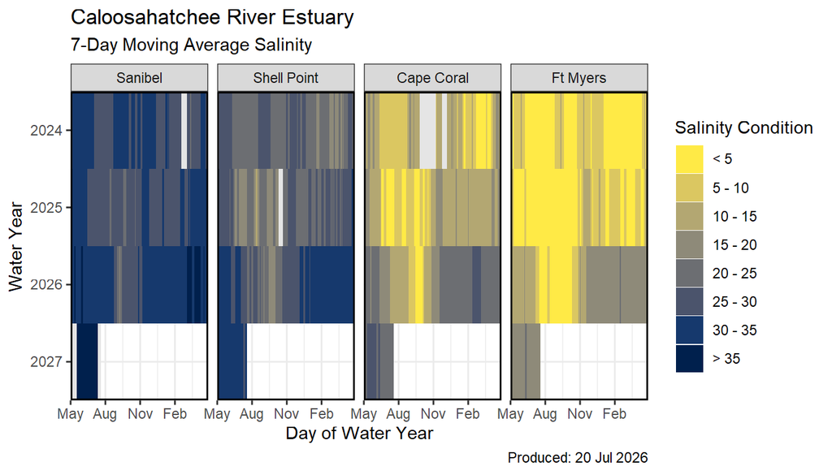

Caloosahatchee River Estuary salinity calendar plot.